# Programs: Replication and Reproducibility in Social Sciences and Statistics: Context, Concerns, and Concrete Measures

Lars Vilhuber

2019-06-28

# 1 Program directory

This directory contains all programs necessary to run the download and analysis. They can be run separately, or from the master document (this README).

## 1.1 Setup

Most parameters are set in the `config.R`:

Any libraries needed are called and if necessary installed through `libraries.R`:

## 1.2 Download the survey data from Google Sheet

The responses to the surveys are stored on Google Sheets. Programs make no attempt to verify if the data previously downloaded (in ../data/survey_data) are older than the data on the web. In order to update the data, delete the relevant file, and run the programs again. The following program is NOT automatically run when executing this README - change the `eval=FALSE` to `eval=TRUE` to run it, or run it manually.

```r
source(file.path(programs,"01_download_surveys.R"),echo=TRUE)
```

## 1.3 Combine various sites into one file

We combine the various files - it evolves a bit over time, so we need to possibly do some consolidation.

```r
source(file.path(programs,"02_combine_surveys.R"),echo=TRUE)
```

```
##
## > ws <- readRDS(file = file.path(dataloc, "mapping_ws_nums.Rds"))
##
## > ws <- as.vector(ws$ws)
##
## > for (x in 1:length(ws)) {
## +     tmp.outfile <- paste0("surveyQ_", ws[x])
## +     tmp.ws <- readRDS(file = file.path(dataloc, paste0(tmp.outfile,
## +    .... [TRUNCATED]
##
## > surveys <- rename(surveys, location = worksheet)
##
## > saveRDS(surveys, file = file.path(interwrk, "surveys.Rds"))
```

## 1.4 Core analysis and figures

We can now tabulate the results from the survey.

### 1.4.1 Published?

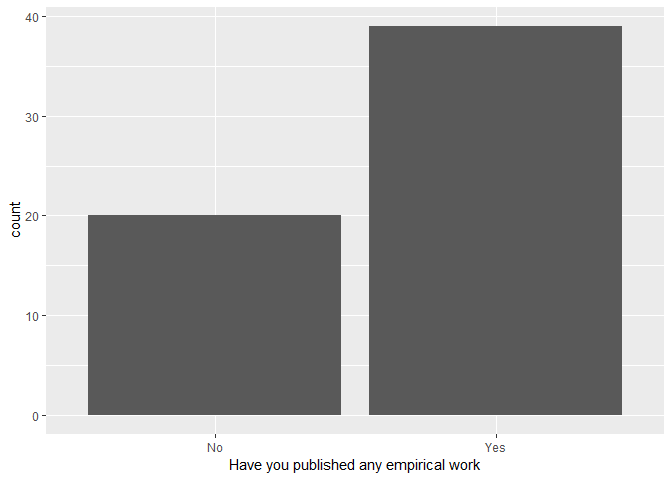

### Knowledge of Github, by faculty status

[figure not shown]

[figure not shown]

### 1.4.2 Do you archive?

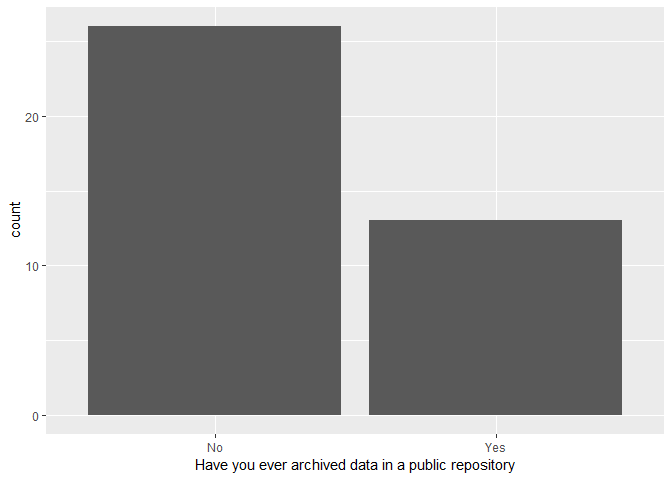

### Do you publish your code?

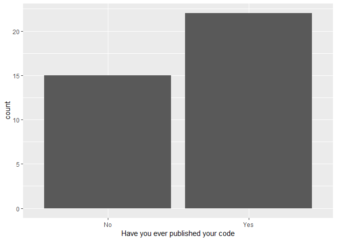